# Data Analysis of Airbnb Pricing Data

The calendar pricings of over 15000 Airbnb listings in Barcelona have been obtained in a raw format. In the following, features will be extracted, explored and used in a predictive model.

```python
import re
import os
import sys
import glob
import bs4
import pprint
import descartes
import pandas as pd
import numpy as np
import scipy.stats as ss
import geopandas as gpd
import matplotlib.pyplot as plt
import seaborn as sns
from shapely.geometry import Point, Polygon

#Set plotting params.
sns.set_style(style='darkgrid',
    rc={'axes.facecolor': '.9', 'grid.color': '.8'})
sns.set_palette(palette='deep')
sns_c = sns.color_palette(palette='deep')
```

```python
plt.rcParams['figure.figsize'] = [10, 6]
```

The calendar and price data is located in several csv-files on disk and contain a dictionaries for each listing's calendar data. The data has to be loaded into a dataframe and then the desired pieces information can be parsed from the Dict.

```python
%%time
#Parse calendar info from disk and concatenate files.
dir_name = '/Users/maximiliankunz/Documents/PyScripts/scrapeAirbnb/' \
           '14.09.20_scrape/calendar_data'
path_list = glob.glob(dir_name + '/CALENDARDICT*.csv')
l=[0]*len(path_list)
for i in range(len(path_list)):
    l[i] = pd.read_csv(path_list[i], header=0, index_col=0)

#For exploration, only use first 20 lists, as otherwise the processing times get out of hand.
#This is a result of the vast amount of data. Explore with less data and run all data through the notebook
#at the end.
calendar_raw = pd.concat(l, ignore_index=True, axis=0)
```

```
CPU times: user 45 s, sys: 7.7 s, total: 52.7 s
Wall time: 1min
```

```python
%%time
#Run through eval to extract dict from string.
calendar_raw.dict = calendar_raw.dict.apply(lambda x: eval(x))
```

```
CPU times: user 10min 51s, sys: 2min 17s, total: 13min 8s
Wall time: 14min 16s
```

The data sits in a very nested dictionary. We'll need a function to retrieve interesting information. After looking at the nesting, the most interesting features can be pulled out of the dict lie that:

```python
%%time
feature_list = ['date', 'available', 'max_nights', 'min_nights',
                'bookable', 'price', 'listing_id']

#Func to handle the parsing.
def get_listing_data(i):
    numpy_skel = np.array(feature_list).reshape(1,-1)

    listing_level = calendar_raw.iloc[i,1]
    listing_id = calendar_raw.iloc[i,0]
    month_level = listing_level['data']['merlin']['pdpAvailabilityCalendar']['calendarMonths']

    for month in range(len(month_level)):
        day_level = month_level[month]['days']
        for day in range(len(day_level)):
            day_values = np.array((day_level[day]['calendarDate'],
                                day_level[day]['available'],
                                day_level[day]['maxNights'],
                                day_level[day]['minNights'],
                                day_level[day]['bookable'],
                                day_level[day]['price']['localPriceFormatted'],
                                month_level[0]['listingId'],
                                 )).reshape(1,-1)
            numpy_skel = np.append(numpy_skel,day_values,axis=0)

    single_l_data = pd.DataFrame(numpy_skel,
                                 columns=feature_list).drop(0).reset_index(drop=True)
    return single_l_data
```

```
CPU times: user 33 µs, sys: 38 µs, total: 71 µs
Wall time: 56 µs
```

```python
%%time
#Parsing loop.
all_data = []
for listing in range(len(calendar_raw)):
    try:
        all_data.append(get_listing_data(listing))
    except TypeError:
        pass
```

```
CPU times: user 2min 58s, sys: 26.6 s, total: 3min 25s
Wall time: 3min 54s
```

```python
all_frame = pd.concat(all_data,axis=0,ignore_index=True)
del(calendar_raw)
```

We can turn the timestamp into different time series features with .datetime

```python
all_frame.date = pd.to_datetime(all_frame.date, format='%Y-%m-%d')
all_frame.loc[:,'year'] = all_frame.date.dt.year
all_frame.loc[:,'month'] = all_frame.date.dt.month
all_frame.loc[:,'week'] = all_frame.date.dt.weekofyear
all_frame.loc[:,'day'] = all_frame.date.dt.dayofyear
all_frame.loc[:,'weekday'] = all_frame.date.dt.dayofweek
```

```python
all_frame['available'] = all_frame['available'].astype(bool)
all_frame['bookable'] = all_frame['bookable'].astype(bool)
all_frame['min_nights'] = all_frame['min_nights'].astype(int)
all_frame['max_nights'] = all_frame['max_nights'].astype(int)
```

# Explore prices + Data cleaning.

```python
all_frame.head()
```

|  | date | available | max_nights | min_nights | bookable | price | listing_id | year | month | week | day | weekday |
| --- | --- | --- | --- | --- | --- | --- | --- | --- | --- | --- | --- | --- |
| 0 | 2020-09-01 | False | 27 | 1 | False | €39 | 17471169 | 2020 | 9 | 36 | 245 | 1 |
| 1 | 2020-09-02 | False | 27 | 1 | False | €39 | 17471169 | 2020 | 9 | 36 | 246 | 2 |
| 2 | 2020-09-03 | False | 27 | 1 | False | €39 | 17471169 | 2020 | 9 | 36 | 247 | 3 |
| 3 | 2020-09-04 | False | 27 | 1 | False | €39 | 17471169 | 2020 | 9 | 36 | 248 | 4 |
| 4 | 2020-09-05 | False | 27 | 1 | False | €39 | 17471169 | 2020 | 9 | 36 | 249 | 5 |

There is a data point for each listing for each day 365 days into the future. The dataset contains a "available" and "bookable" feature, whose meaning has to be explored.

As realistic pricing data is most likely to be expected from days that are actually bookable by guests, we drop the rows with "available" = False. NaN values will also be dropped.

```python
cal_df = all_frame.loc[((~all_frame.price.isna()) \
                       & (all_frame.available==True))] \
        .copy()
#cal_df = all_frame.loc[~all_frame.price.isna()].copy()#Drop NA and unavailable.
cal_df.price = cal_df.price.apply(lambda x: x.replace(',','').replace('€','')).astype(int) #Clean price values.
```

To get a feeling for the distribution, we can calculate the average nightly price for each listing and look at the distribution.

```python
idx_slice = pd.IndexSlice
avrg_daily = cal_df.groupby(['listing_id'])['price'].mean().to_frame()
```

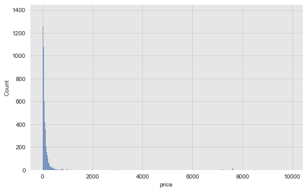

```python
f,ax=plt.subplots(figsize=(8,5))
sns.histplot(avrg_daily.price)
```

We see most values far below 1000€/night, which seems reasonable. However, the histogram stretches until 8000€/night, but without showing a visible column for the values, which means there are very few listings with extremely high nightly prices. There is also a peak at the 0€ mark, which is a price not possible for a bookable night. These will have to be dropped.

```python
avrg_daily[avrg_daily.price>2000].head() #Some avalues are strangely big.
```

| listing_id | price |
| --- | --- |
| 10621483 | 7636.225000 |
| 10920893 | 7576.094183 |
| 11197896 | 7615.686981 |
| 11290289 | 2063.885965 |
| 1198074 | 3498.094444 |

```python
cal_df[cal_df.price == 0].shape #Some prices are zero -> drop zero
```

```
(313, 12)
```

```python
cal_df.drop(cal_df[cal_df.price == 0].index, axis=0,inplace=True)
```

Assume that listings with wrong pricing (H made mistake) have high discrepancy between median and mean nightly prices. Detect those listings:

```python
#Helperfunc to calculate ration between mean and median.
def mean_vs_median(df):
    mean_vs_median = pd.concat([df.groupby(['listing_id'])['price'].mean(),
                                df.groupby(['listing_id'])['price'].median()],
                                axis=1)
    mean_vs_median.columns = ['mean','median']
    mean_vs_median = mean_vs_median.assign(median_mean_ratio=mean_vs_median['mean']
                                           / mean_vs_median['median'])
    print(mean_vs_median.median_mean_ratio.hist())
    return mean_vs_median.median_mean_ratio
```

```
AxesSubplot(0.125,0.125;0.775x0.755)
```

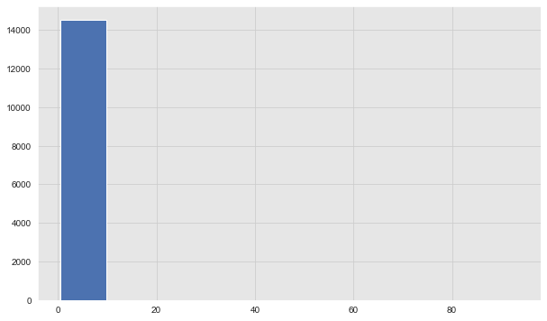

```python
mistakes = mean_vs_median(cal_df)
```

Most listings have a realistic reation between mean and median between 1 and 10, while the histogram reaches until 80. Some listings can be expected to have wrong pricing, meaning that the host doesnt really pay attention to the pricing and made a mistake, or some other bias factors that have to be explored. Let's look at the highest values possible

```python
cal_df.price.max()
```

```
18300
```

```python
cal_df[(cal_df.listing_id=='1338956') & (cal_df.month == 1)].head()
```

|  | date | available | max_nights | min_nights | bookable | price | listing_id | year | month | week | day | weekday |
| --- | --- | --- | --- | --- | --- | --- | --- | --- | --- | --- | --- | --- |
| 570252 | 2021-01-01 | True | 180 | 1 | True | 9999 | 1338956 | 2021 | 1 | 53 | 1 | 4 |
| 570253 | 2021-01-02 | True | 180 | 1 | True | 9999 | 1338956 | 2021 | 1 | 53 | 2 | 5 |
| 570254 | 2021-01-03 | True | 180 | 1 | True | 9999 | 1338956 | 2021 | 1 | 53 | 3 | 6 |
| 570255 | 2021-01-04 | True | 180 | 1 | True | 9999 | 1338956 | 2021 | 1 | 1 | 4 | 0 |
| 570256 | 2021-01-05 | True | 180 | 1 | True | 9999 | 1338956 | 2021 | 1 | 1 | 5 | 1 |

Some listings have extremly high avrge nightly prices. After exploring those listings, it becomes clear that an unbookable night get default value of 9999€. Interestingly, both variables "bookable" and "available" are True for those nights. Assumption, those dates are manually blocked.

-> Remove 9999 prices.

```python
cal_df.drop(cal_df.loc[cal_df.price >= 9999].index, axis=0, inplace=True)
assert cal_df.loc[cal_df.price >= 9999].shape[0] == 0 #No 9999 prices remaining.
```

Let's have a look at the mean and median price values after the first cleaning operation.

```python
avrg_daily = cal_df.groupby(['listing_id'])['price'].mean().to_frame()
print(f'Mean nightly price in city: {round(avrg_daily.mean().values[0], 1)}€/night')
print(f'Median nightly price in city: {round(avrg_daily.median().values[0], 1)}€/night')
```

```
Mean nightly price in city: 112.7€/night
Median nightly price in city: 64.6€/night
```

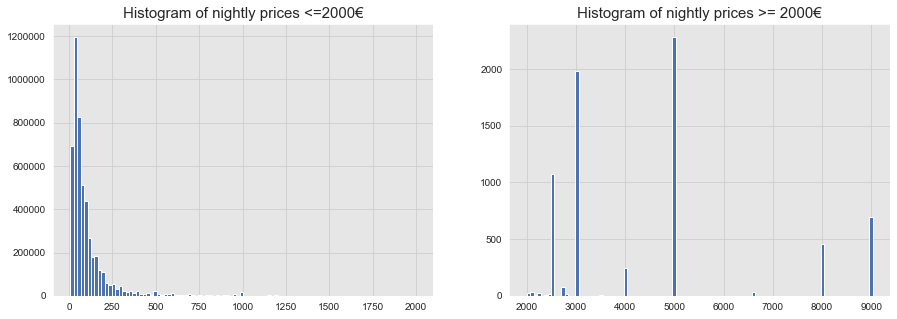

```python
f, axes = plt.subplots(1,2,figsize=(15,5), sharex=False, sharey=False)
axes[0].set_title('Histogram of nightly prices <=2000€', fontsize=15)
cal_df[cal_df.price<=2000]['price'].hist(bins=100, ax=axes[0])
axes[1].set_title('Histogram of nightly prices >= 2000€', fontsize=15)
cal_df[cal_df.price>2000]['price'].hist(bins=100, ax=axes[1])
```

```
AxesSubplot(0.125,0.125;0.775x0.755)
```

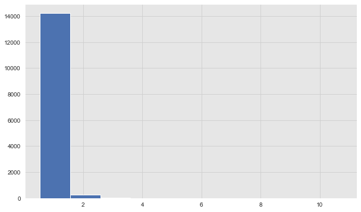

```python
mistakes = mean_vs_median(cal_df)
```

Median/mean rule now better. We have still some outliers present. Lets see which listings are responsible for it.

The histograms of the nightly prices indicates a realistic distribution for values lower than 1000€. For prices beyond that, we see spikes in the extremely high price ranges. That would only make sense for top level luxury accommodation. We can apply some automated metrics to show how realistic there prices are and we can manually review the listing pages on Airbnb, to see if the housing is top level luxury.

```python
cal_df[cal_df.price>2000].groupby(['listing_id'])['price'].median()
```

```
listing_id
10065521    3500.0
1098894     2100.0
12567485    2500.0
1269253     2395.0
1269263     2588.0
             ...
44890231    6580.0
4996306     2500.0
536470      8000.0
5463970     2775.0
5494667     2500.0
Name: price, Length: 70, dtype: float64
```

```python
cal_df[(cal_df.price>=8000)].listing_id.unique() #Some have even more than 9999€ -> not available
#L with id 21670614 is a low value private room, with price of 9000€ -> mistake
#3 listings have prices higher than 8000 still. Possible?
#Manually checked: only 17211611 is luxury yacht -> possible
#Other 2 are mistakes
```

```
array(['17211611', '19882937', '21670614', '36241040', '3184195',
       '536470'], dtype=object)
```

```
AxesSubplot(0.125,0.125;0.775x0.755)
```

```
listing_id
17211611     1.000000
19882937     8.510221
21670614     1.000000
3184195      2.534002
36241040     1.000000
536470      10.740437
Name: median_mean_ratio, dtype: float64
```

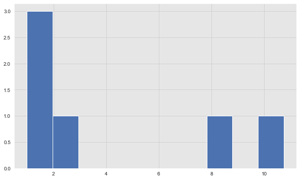

```python
mean_vs_median(cal_df[cal_df.listing_id.isin(set(cal_df[(cal_df.price>=8000)].listing_id.unique()))])
```

```python
#Drop nights with 8000+ price for listings 19882937, 21670614, 536470, 3184195, 36241040
#Manually checked!
cal_df.drop(cal_df.loc[(cal_df.price >= 7999)&
                       (cal_df.listing_id.isin(
                           set(['19882937', '21670614', '536470',
                                '3184195', '36241040'])))].index,
            axis=0, inplace=True)
```

```python
avrg_daily = cal_df.groupby(['listing_id'])['price'].mean().to_frame()
print(f'Mean nightly price in city: {round(avrg_daily.mean().values[0], 1)}€/night')
print(f'Median nightly price in city: {round(avrg_daily.median().values[0], 1)}€/night')
```

```
Mean nightly price in city: 111.3€/night
Median nightly price in city: 64.6€/night
```

### Now check prices with 3000€+

```python
cal_df[(cal_df.price>=3000)].listing_id.unique()
```

```
array(['35296924', '17471127', '44470011', '43861096', '34492738',
       '13811701', '44890231', '13824615', '41468412', '37278198',
       '37990824', '19115344', '17211611', '29530487', '29530310',
       '18945052', '5494667', '19645783', '16607374', '37990758',
       '29530449', '13663333', '25758097', '16599705', '10065521',
       '43858509', '20472744', '13808970'], dtype=object)
```

```python
cal_df[(cal_df.listing_id=='29530310') & (cal_df.price >1000)]
```

|  | date | available | max_nights | min_nights | bookable | price | listing_id | year | month | week | day | weekday |
| --- | --- | --- | --- | --- | --- | --- | --- | --- | --- | --- | --- | --- |
| 1308616 | 2020-12-01 | True | 1125 | 1 | True | 6599 | 29530310 | 2020 | 12 | 49 | 336 | 1 |
| 1308617 | 2020-12-02 | True | 1125 | 1 | True | 6599 | 29530310 | 2020 | 12 | 49 | 337 | 2 |
| 1308705 | 2021-02-28 | True | 1125 | 1 | True | 6599 | 29530310 | 2021 | 2 | 8 | 59 | 6 |
| 1308706 | 2021-03-01 | True | 1125 | 1 | True | 6599 | 29530310 | 2021 | 3 | 9 | 60 | 0 |
| 1308707 | 2021-03-02 | True | 1125 | 1 | True | 6599 | 29530310 | 2021 | 3 | 9 | 61 | 1 |
| 1308708 | 2021-03-03 | True | 1125 | 1 | True | 6599 | 29530310 | 2021 | 3 | 9 | 62 | 2 |
| 1308825 | 2021-06-28 | True | 1125 | 1 | True | 6599 | 29530310 | 2021 | 6 | 26 | 179 | 0 |
| 1308826 | 2021-06-29 | True | 1125 | 1 | True | 6599 | 29530310 | 2021 | 6 | 26 | 180 | 1 |
| 1308827 | 2021-06-30 | True | 1125 | 1 | True | 6599 | 29530310 | 2021 | 6 | 26 | 181 | 2 |
| 1308828 | 2021-07-01 | True | 1125 | 1 | True | 6599 | 29530310 | 2021 | 7 | 26 | 182 | 3 |
| 1308829 | 2021-07-02 | True | 1125 | 1 | True | 6599 | 29530310 | 2021 | 7 | 26 | 183 | 4 |

```
AxesSubplot(0.125,0.125;0.775x0.755)
```

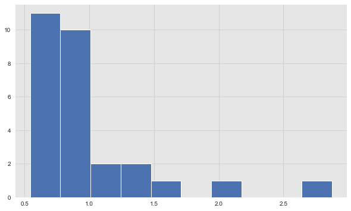

```python
over_3000 = mean_vs_median(cal_df[cal_df.listing_id.isin(
    set(cal_df[(cal_df.price >= 3000)].listing_id.unique())
)])
```

After investigating some listings, it becomes evident, that a mean/median ration that is significantly lower than 1.0 is suspicious, as it indicates that probably a large portion of nights are significantly higher in price than the average. Only that way, the median can be significantly bigger than the mean. Ratios close to 1 and slightly bigger make more sense and indicate normal price variations. 35296924 wrong price!

Check manually: 10065521 correct 13663333 wrong 13808970 wrong 13811701 wrong 13824615 wrong 16599705 wrong 16607374 wrong 17211611 correct 17471127 correct 18945052 wrong 19115344 wrong 19645783 wrong 25758097 wrong 29530310 wrong 29530449 wrong 29530487 wrong 34492738 wrong 35296924 wrong 37278198 wrong 44890231 wrong 37990824 wrong

Almost all manually checked listings were wrongly priced by mistakes. Only 3 could be confirmed to be realistic. THe assumtion that a median/mean ration of around 0.5 indicates a wrong price holds true. I will not check all manually and remove all, except the 3 that were confirmed true.

```python
over_3000 = list(over_3000.index.values)
for true_id in ['10065521','17211611','17471127']: #remove realistic listings
    over_3000.remove(true_id)
```

```python
cal_df.drop(cal_df.loc[(cal_df.price >= 2999)&
                       (cal_df.listing_id.isin(set(over_3000)))].index,
            axis=0, inplace=True)
```

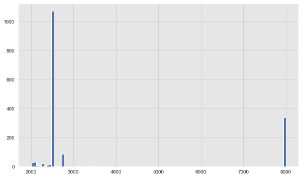

```python
cal_df[cal_df.price > 2000]['price'].hist(bins=100)
#The 8000/night values are from the luxury yacht.
#INvestigate the high peak at around 2500
```

```
AxesSubplot(0.125,0.125;0.775x0.755)
```

```
listing_id
10065521    1.158227
12567485    1.223457
17582798    1.275582
20472744    0.832788
20472746    0.944099
29398318    0.688774
32088715    1.000000
39617654    0.550455
4200509     0.955153
42994317    1.163582
4996306     1.401625
5494667     0.810235
Name: median_mean_ratio, dtype: float64
```

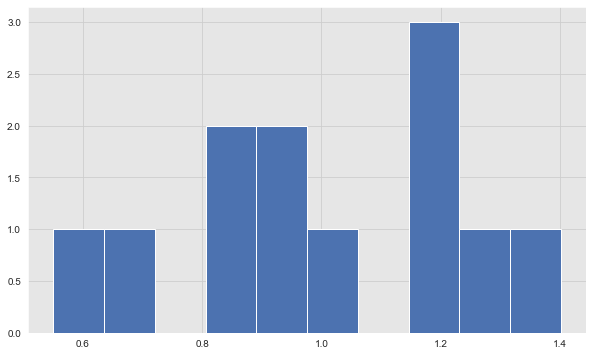

```python
cal_df[(cal_df.price>2450)&(cal_df.price<2600)].listing_id.unique()
mean_vs_median(cal_df[cal_df.listing_id.isin(
    set(cal_df[(cal_df.price>2450) & (cal_df.price<2600)]
        .listing_id.unique()))])
```

```python
#All manually checked. Only listing that is unrealistic is: 39617654 -> remove
cal_df.drop(cal_df.loc[(cal_df.price>2450)
                       & (cal_df.price<2600)
                       & (cal_df.listing_id.isin(set(['39617654'])))].index,
            axis=0, inplace=True)
```

The cleaning of outlierts is finished and the final distribution and metrics of prices can be plotted.

```python
avrg_daily = cal_df.groupby(['listing_id'])['price'].mean().to_frame()
print(f'Mean nightly price in city: {round(avrg_daily.mean().values[0], 1)}€/night')
print(f'Median nightly price in city: {round(avrg_daily.median().values[0], 1)}€/night')
```

```
Mean nightly price in city: 107.6€/night
Median nightly price in city: 64.3€/night
```

Time progrssion of the nightly price on a year, month, calendar week and weekday level.

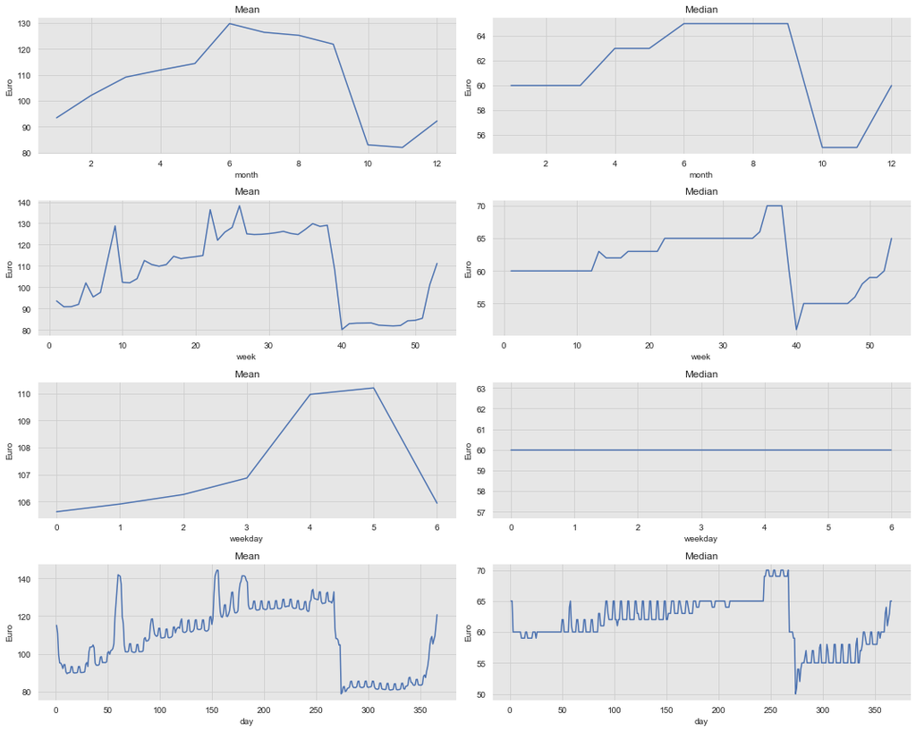

```python
f, axes = plt.subplots(4, 2, figsize=(15,12), sharey=False)
i = 1
for t in ['month', 'week', 'weekday', 'day']:
    plt.subplot(4, 2, i)
    plt.title('Mean')
    plt.ylabel('Euro')
    mean = cal_df.groupby([t])['price'].mean()
    mean.plot(kind='line', sharey=False)
    plt.subplot(4, 2, i+1)
    plt.title('Median')
    plt.ylabel('Euro')
    cal_df.groupby([t])['price'].median().plot(kind='line')
    i+=2
f.tight_layout()
```

# Explore "min_nights"

```python
night_df = all_frame.copy()
```

```python
night_df.min_nights.isna().any()
```

```
False
```

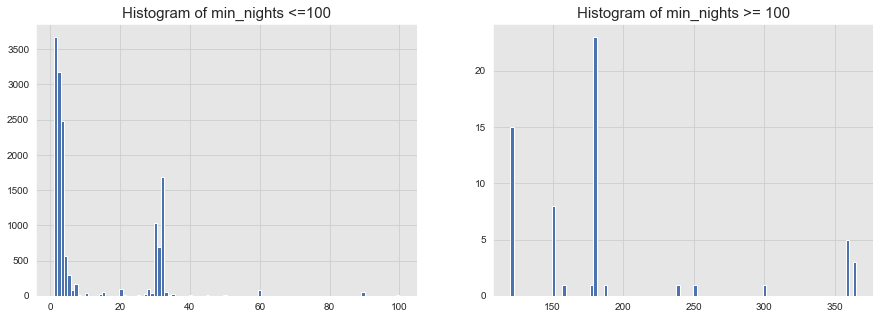

```python
f, axes = plt.subplots(1,2,figsize=(15,5), sharex=False, sharey=False)

axes[0].set_title('Histogram of min_nights <=100', fontsize=15)
night_df[night_df.min_nights <= 100] \
    .groupby(['listing_id'])['min_nights'] \
    .median() \
    .hist(bins=100,ax=axes[0])

axes[1].set_title('Histogram of min_nights >= 100', fontsize=15)
night_df[night_df.min_nights > 100] \
    .groupby(['listing_id'])['min_nights'] \
    .median() \
    .hist(bins=100,ax=axes[1])
```

# Explore "max_nights"

```python
night_df.max_nights.isna().any()
```

```
False
```

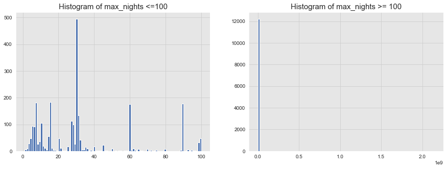

```python
f, axes = plt.subplots(1,2,figsize=(15,5), sharex=False, sharey=False)

axes[0].set_title('Histogram of max_nights <=100', fontsize=15)
night_df[night_df.max_nights<=100] \
    .groupby(['listing_id'])['max_nights'] \
    .median() \
    .hist(bins=100,ax=axes[0])
axes[1].set_title('Histogram of max_nights >= 100', fontsize=15)
night_df[night_df.max_nights>100] \
    .groupby(['listing_id'])['max_nights'] \
    .median() \
    .hist(bins=100,ax=axes[1])
```

```python
night_df[night_df.max_nights>2000].max_nights.value_counts()
#2 listings have impossible values for max_nights.
```

```
9999          4024
3000          1095
2147483647    1095
Name: max_nights, dtype: int64
```

```python
night_df.drop(night_df[night_df.max_nights>2000].index,
              axis=0,
              inplace=True)
```

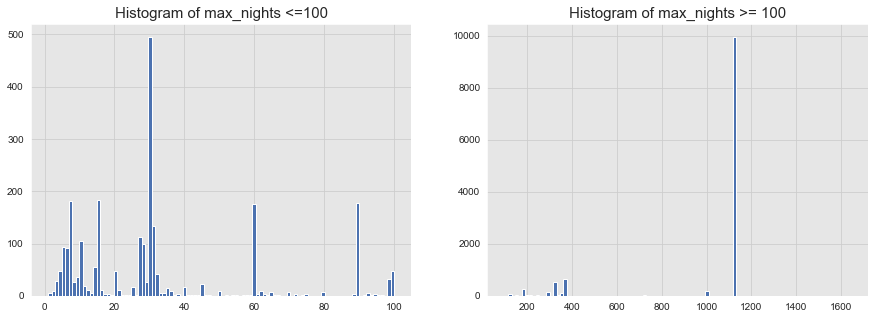

```python
f, axes = plt.subplots(1,2,figsize=(15,5), sharex=False, sharey=False)

axes[0].set_title('Histogram of max_nights <=100', fontsize=15)
night_df[night_df.max_nights<=100] \
    .groupby(['listing_id'])['max_nights'] \
    .median() \
    .hist(bins=100,ax=axes[0])

axes[1].set_title('Histogram of max_nights >= 100', fontsize=15)
night_df[night_df.max_nights>100] \
    .groupby(['listing_id'])['max_nights'] \
    .median() \
    .hist(bins=100,ax=axes[1])
```

#### 1125 is default value for max night restrictions.

# Explore "available"

```python
all_frame.available.value_counts()
```

```
True     5118803
False     208007
Name: available, dtype: int64
```

# Explore "bookable"

```python
all_frame.bookable.value_counts()
```

```
True     5115641
False     211169
Name: bookable, dtype: int64
```

Both variable dont seem to have much to do with the actual availability of a caldendar date, is it was often visible in the price analysis, that days that are booable and available are greyed out on the actual Airbnb listing page.

# Combine location data with price

#### Get listings info from old inventory first.

```python
exclusive = pd.read_csv(
    '/Users/maximiliankunz/Documents/PyScripts/'
    'scrapeAirbnb/14.09.20_scrape/exclusive_new.csv'
    )
intersect = pd.read_csv(
    '/Users/maximiliankunz/Documents/PyScripts/'
    'scrapeAirbnb/14.09.20_scrape/new_intersect_included.csv'
    )
inters = set(intersect.values.ravel().tolist()) \
    .difference(set(exclusive.values.ravel().tolist()))
```

```python
path_list_entire = glob.glob('./entire_homes/listing_data/[0-9]*_to_*.csv')
l = [0] * len(path_list_entire)
for i in range(len(path_list_entire)):
    l[i] = pd.read_csv(path_list_entire[i], header=0, index_col=0)

entire_homes = pd.concat(l, ignore_index=True, axis=0)
```

```python
path_list_private = glob.glob('./private_room_inv/listing_data/[0-9]*_to_*.csv')
l = [0] * len(path_list_private)
for i in range(len(path_list_private)):
    l[i] = pd.read_csv(path_list_private[i], header=0, index_col=0)

private_rooms = pd.concat(l, ignore_index=True, axis=0)
```

```python
path_list_shared = glob.glob('./shared_rooms/listing_data/[0-9]*_to_*.csv')
l = [0] * len(path_list_shared)
for i in range(len(path_list_shared)):
    l[i] = pd.read_csv(path_list_shared[i], header=0, index_col=0)

shared_rooms = pd.concat(l, ignore_index=True, axis=0)
```

```python
listings = entire_homes.append([private_rooms, shared_rooms])
listings.neighborhood_id = listings.neighborhood_id.astype('str')
#listings = listings.loc[:,['listing_id','listing_lat','listing_long']]
listings = listings[listings.listing_id.isin(inters)]
```

#### Get listing info from new inventory.

```python
path_list_new = glob.glob('./14.09.20_scrape/listing_data/[0-9]*_to_*.csv')
l = [0] * len(path_list_new)
for i in range(len(path_list_new)):
    l[i] = pd.read_csv(path_list_new[i], header=0, index_col=0)

new_homes = pd.concat(l, ignore_index=True, axis=0)
#new_homes = new_homes.loc[:,['listing_id','listing_lat','listing_long']]
```

```python
# Assert checking if new listing data corresponds to the new found listings completely.
assert new_homes.shape[0] == len(set(exclusive.values.ravel().tolist()) \
                                 .intersection(set(new_homes.listing_id.values.ravel().tolist())))

#Assert checking if old L info doesnt intersect with new L info.
assert len(set(listings.listing_id.values.ravel().tolist()) \
           .intersection(set(new_homes.listing_id.values.ravel().tolist()))) == 0
```

```python
listing_info = listings.append(new_homes).reset_index(drop=True)
listing_info.listing_id = listing_info.listing_id.astype(str)
assert listing_info.listing_id.shape == listing_info.listing_id.unique().shape
```

```python
#Merge pricing data with listing information.
price_loc = listing_info.merge(
    cal_df.groupby(['listing_id'])['price'].mean().to_frame(name='avg_price'),
    on='listing_id')
price_loc = price_loc.merge(
    cal_df.groupby(['listing_id'])['price'].median().to_frame(name='median_price'),
    on='listing_id')
```

```python
price_loc.neighborhood_id = price_loc.neighborhood_id.astype('str')
price_loc.num_bedrooms.where(price_loc.num_bedrooms != 'S', 1, inplace=True)
price_loc.num_bedrooms = price_loc.num_bedrooms.astype(int)
price_loc.num_bath.where(price_loc.num_bath != '1', 1, inplace=True)
price_loc.num_bath.where(price_loc.num_bath != 'H', 0.5, inplace=True)
price_loc.num_bath.where(price_loc.num_bath != 'S', 1.0, inplace=True)
price_loc.num_bath.where(price_loc.num_bath != 'P', 1.0, inplace=True)
price_loc.num_bath = price_loc.num_bath.astype(float)
price_loc.superhost = price_loc.superhost.astype(bool)
price_loc.verified = price_loc.verified.astype(bool)
```

```python
price_loc.info()
```

```
<class 'pandas.core.frame.DataFrame'>
Int64Index: 14163 entries, 0 to 14162
Data columns (total 25 columns):
 #   Column           Non-Null Count  Dtype
---  ------           --------------  -----
 0   listing_id       14163 non-null  object
 1   num_guests       14163 non-null  int64
 2   num_bedrooms     14163 non-null  int64
 3   num_beds         14163 non-null  int64
 4   num_bath         14163 non-null  float64
 5   superhost        14163 non-null  bool
 6   verified         14163 non-null  bool
 7   room_type        14163 non-null  object
 8   neighborhood_id  14163 non-null  object
 9   listing_lat      14163 non-null  float64
```

[output cut: 17 more lines]

## Excursion: Creating a tesselation of listing coors for density and price plots with Prpcessing

```python
from scipy.spatial import Delaunay
tess_df = price_loc.copy()
tri = Delaunay(tess_df.loc[:, ['listing_lat', 'listing_long']])
simplices = pd.DataFrame(tri.simplices)
simplices.columns = ['corner1', 'corner2', 'corner3']
```

```python
#tess_df.to_csv('/Users/maximiliankunz/Documents/Processing/PriceTesselation/data/listing_data.csv')
#simplices.to_csv('/Users/maximiliankunz/Documents/Processing/PriceTesselation/data/tri.csv')
```

```python
def triangle_area(tri): #Area of a triangle from coors.
    x1, y1, x2, y2, x3, y3 = tri[0][0], tri[0][1], tri[1][0], tri[1][1], tri[2][0], tri[2][1]
    return abs(0.5 * (((x2-x1)*(y3-y1))-((x3-x1)*(y2-y1))))
```

```python
simplices['areas'] = np.array(list(map(triangle_area,
                                       tess_df.loc[:,['listing_lat','listing_long']] \
                                           .values[tri.simplices])))
simplices.columns = ['simp_0', 'simp_1', 'simp_3', 'areas']
```

```python
%%time
#Create density values of tesselation.
area_sums = np.zeros(len(tess_df))
for i in range(len(tess_df)):
    areas = [
        simplices.areas[triangle] for triangle in range(len(tri.simplices)) if i in set(tri.simplices[triangle])
        ]
    area_sums[i] = sum(areas)
    if i%1000 == 0:
        print('Progress:',round(i/len(tess_df)*100,1),'%')
```

```python
point_areas = area_sums.copy()
zero_idx = pd.Series(point_areas)[pd.Series(point_areas)<=2e-9].index
point_areas = np.delete(point_areas,zero_idx,axis=0) #Remove 0 values.
tess_df.drop(zero_idx,axis=0,inplace=True)
tess_df = tess_df.reset_index(drop=True)
```

```python
#Redo tesselation because of deleted coors.
tri = Delaunay(tess_df.loc[:,['listing_lat','listing_long']])
simplices = pd.DataFrame(tri.simplices)
simplices.columns = ['corner1','corner2','corner3']
```

```python
assert tess_df.shape[0] == point_areas.shape[0] #Assert to verify shapes match
```

```python
def custom_norm(v):
    v_min, v_max = v.min(), v.max()
    return (v-v_min)/(v_max-v_min)
```

```python
#Concat frames and save to Processing.
df = pd.concat([tess_df.loc[:,['listing_id','listing_lat','listing_long']],
                pd.DataFrame(1/point_areas),density_bins,price_bins],
               axis=1,
               join='inner')
df.columns=['listing_id', 'listing_lat', 'listing_long', 'price',
            'density', 'density_bins', 'price_bins']
df.density = df.density.apply(lambda x: x/1e+04)
```

```python
#Create quantile bins.
price_bins = pd.qcut(df.price,10)
density_bins = pd.qcut(df.density,10)

#Turn into str to turn them into int categories.
density_bins = density_bins.apply(lambda x : str(x)) #Obj to str
price_bins = price_bins.apply(lambda x : str(x)) #Obj to str

density_bins = density_bins.map(
    dict(zip(density_bins.value_counts(sort=False).index.values,
             range(1,len(density_bins.unique())+1)))
) #Str to int.
price_bins = price_bins.map(
    dict(zip(price_bins.value_counts(sort=False).index.values,
             range(1,len(price_bins.unique())+1)))
) #Str to int.
```

DIRNAME = '/Users/maximiliankunz/Documents/Processing/tesselations/sandwitchTesselation/data' df.to_csv(DIRNAME + '/listing_data.csv') simplices.to_csv(DIRNAME + '/tri.csv')

The result of this approach, drawn in Processing and Adobe Illustrator, can be seen here.

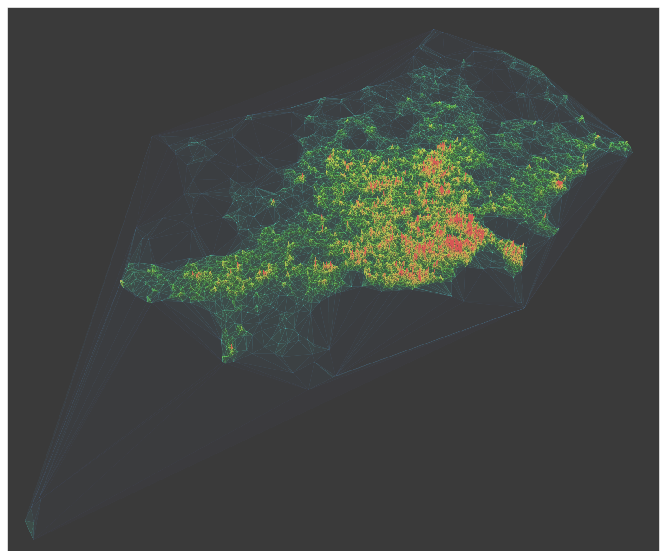

```python
tessellation = plt.imread('/Users/maximiliankunz/Documents/Processing/'
                          'tesselations/sandwitchTesselation/densepic-01.png')

f , ax = plt.subplots(figsize=(13,10))
ax.imshow(tessellation,aspect='equal')
_ = ax.set(xticks=[],yticks=[])
```

# Data analysis of price feature combined with listing data.

First let's plot simple correlations between the numeric features to have first insights into relationships between the variables. As there is only one luxus yacht listing (which is nteresting in itself), but is an outlier with a mean price of 8000€ (54 $\sigma$) that skews the metrics and visualization, we'll drop that data point, to have a better insight into the features' relationsship with the price.

```python
price_loc.drop(price_loc.loc[price_loc.avg_price>7999].index, axis=0, inplace=True)
```

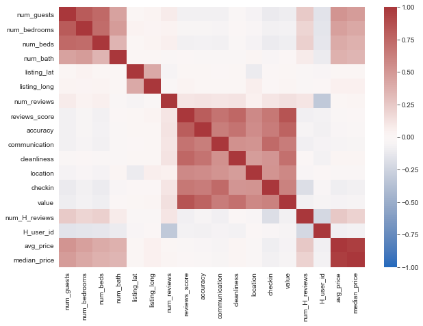

```python
sns.set_style(style='darkgrid',
    rc={'axes.facecolor': '.9', 'grid.color': '.8'})

numerics = ['int16', 'int32', 'int64', 'float16', 'float32', 'float64']
f,ax=plt.subplots(figsize=(10,7))
sns.heatmap(price_loc.select_dtypes(include=numerics).corr(),
            cmap=sns.color_palette("vlag", as_cmap=True),
            vmin=-1.0)
```

Let's check the categorical correlation with the help of cramers_v.

```python
#Coeff for correlation between 2 categorical columns.
def cramers_v(x, y):
    confusion_matrix = pd.crosstab(x, y)
    chi2 = ss.chi2_contingency(confusion_matrix)[0]
    n = confusion_matrix.sum().sum()
    phi2 = chi2 / n
    r,k = confusion_matrix.shape
    phi2corr = max(0, phi2 - ((k - 1) * (r - 1)) / (n - 1))
    rcorr = r - ((r - 1) ** 2) / (n - 1)
    kcorr = k - ((k - 1) ** 2) / (n - 1)
    return np.sqrt(phi2corr / min((kcorr - 1), (rcorr - 1)))

# Custom correlation calculation in matrix form.
# Directly derived from panda's corr().
def custom_corr(df, func):
    cols = df.columns
    idx = cols.copy()
    mat = df.to_numpy(na_value=np.nan, copy=False)
    mat = mat.T
    corrf = func
    K = len(cols)
    correl = np.empty((K, K), dtype=float)
    for i, ac in enumerate(mat):
        for j, bc in enumerate(mat):
            if i > j:
                continue

            if i == j:
                c = 1.0
            else:
                c = corrf(ac, bc)
            correl[i, j] = c
            correl[j, i] = c
    return pd.DataFrame(correl, index=idx,columns=cols)
```

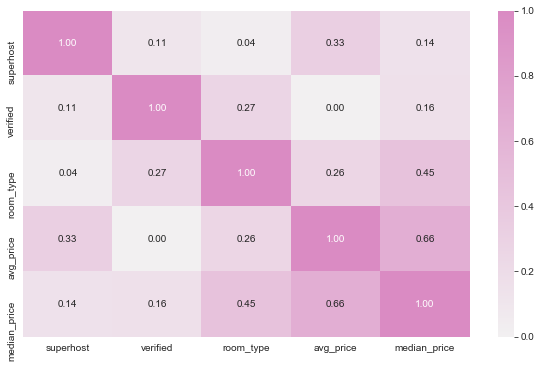

```python
cols = ['superhost', 'verified', 'room_type', 'avg_price', 'median_price']

corr = custom_corr(price_loc.loc[:,cols], cramers_v)
sns.heatmap(corr, cmap=sns.light_palette(sns_c[6], as_cmap=True),
            annot=True, fmt='0.2f')
```

The price seems to have the highest correlation with the number of guests, so lets see if there is a linear relationship.

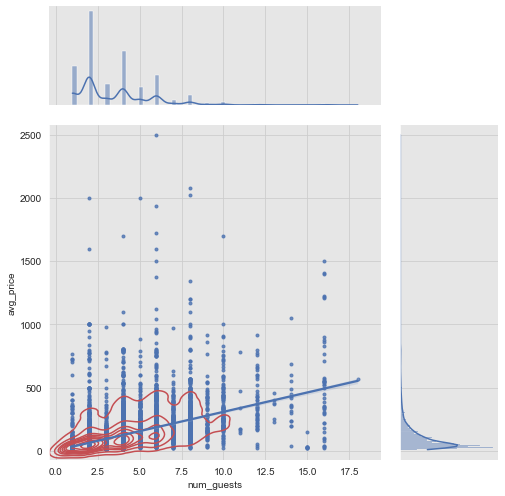

```python
g = price_loc \
    .pipe((sns.jointplot, 'data'),
    kind='reg',
    x='num_guests',
    y='avg_price',
    height=7,
    ratio=3,
    joint_kws={'marker':'.'})
_=g.plot_joint(sns.kdeplot, levels=10, color=sns_c[3])
```

The correlation can be confirmed. The more guests can stay in a listing the higher the price usually.

Apart from the numerical features, the categorical features of room_type and superhost might intuitively a significant impact on the price, which will be explore in the following heatmap of the average price per month, dependent on thesecategoricals.

```python
df = cal_df.merge(listing_info, on='listing_id')
df.drop(['available','description','H_user_id','neighborhood_id'], axis=1, inplace=True)
df.drop(df.loc[df.price == 8000].index, axis=0, inplace=True)
```

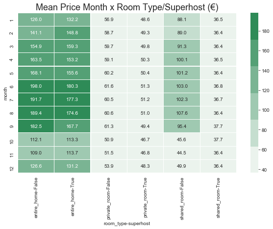

```python
fig, ax = plt.subplots(figsize=(10,6))
cmap = sns.light_palette('seagreen')
pivot = pd.pivot_table(data=df, values='price', index='month',columns=['room_type','superhost'])
sns.heatmap(pivot,annot=True,fmt='.1f',cmap=cmap, linecolor='white',linewidth=0.1)
_=ax.set_title('Mean Price Month x Room Type/Superhost (€)', fontsize=18)
```

There is a clear difference between room types in the monthly price progression, whereas the superhost status seems to play a smaller role. Surprisingly, the listings managed by a superhost seem to be cheaper than the non-superhost kind. We might confirm this with a logistic regression model.

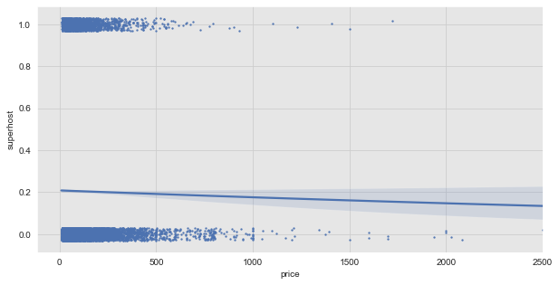

```python
f,ax=plt.subplots(figsize=(10,5))
df.groupby(['listing_id']) \
            .agg({'price':'mean','superhost':'first'}) \
            .pipe((sns.regplot,'data'), x='price', y='superhost',
                  logistic=True, n_boot=500, y_jitter=.03,
                  scatter_kws={'s':2})
```

As expected the probability in being a superhost seems to be slightly negatively linearly connected to the average price of the listings.

Concerning the room types, a violinplot will tell us the difference in price distribution between the types.

```
[]
```

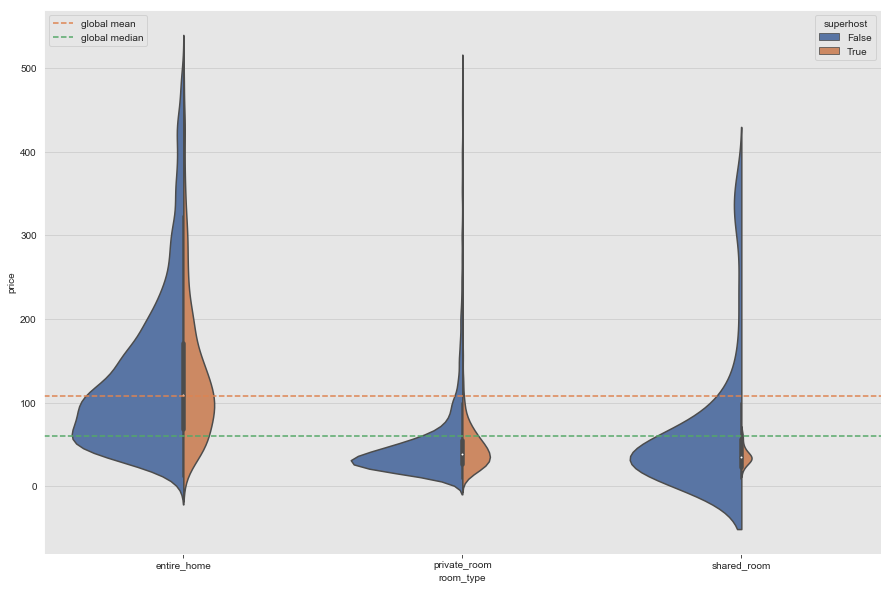

```python
f,ax= plt.subplots(figsize=(15,10))
df.groupby(['listing_id'],as_index=False) \
            .agg({'price':'mean','room_type':'first','superhost':'first'}) \
            .query('price <500') \
            .pipe((sns.violinplot,'data'),x='room_type',y='price',
                  hue='superhost', scale='count', split=True,ax=ax)
ax2 = ax.twiny()
ax2.axhline(y=df.price.mean(), color=sns_c[1], linestyle='--', label='global mean')
ax2.axhline(y=df.price.median(), color=sns_c[2], linestyle='--', label='global median')
ax2.legend(loc='upper left')
ax2.set_xticks([])
```

As a time variable, the month has a big impact on the price, as we have seen above. Maybe on a lower level, we see the sime. For example, the weekend could be more expensive generally that weekdays.

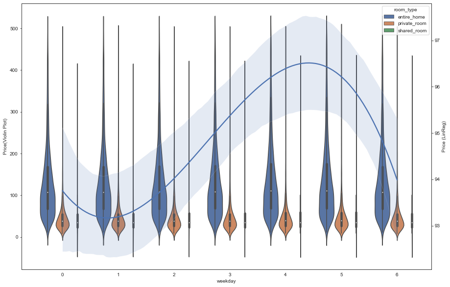

```python
sns.set_style('white')
f, ax1 = plt.subplots(figsize=(15,10))
plot = df.groupby(['listing_id','weekday'],as_index=False) \
            .agg({'price':'mean','room_type':'first'}) \
            .query('price <500')
sns.violinplot(data=plot,x='weekday',y='price',hue='room_type',scale='count',ax=ax1)
ax2 = ax1.twinx()
sns.regplot(data=plot,x='weekday',y='price',scatter=False,ax=ax2,order=3)
ax1.set(ylabel='Price(Violin Plot)')
_=ax2.set(ylabel='Price (LinReg)',label='Lin Reg')
```

There is a difference between weekday, but in the range of a few Euros.

Intuitively, the location of a listing must have an impact on the price. So let's see if we can see a relationship between the location score of the listing from the reviews and the price.

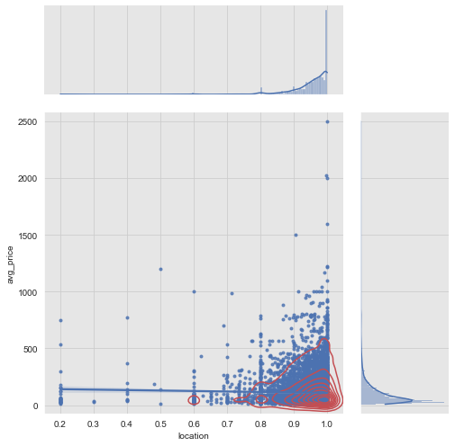

```python
sns.set_style(style='darkgrid',
    rc={'axes.facecolor': '.9', 'grid.color': '.8'})
g = price_loc.pipe((sns.jointplot, 'data'),
              kind='reg',
              x='location',
              y='avg_price',
              height=7,
              ratio=3,
              joint_kws={'marker':'.'})
_=g.plot_joint(sns.kdeplot, levels=10, color=sns_c[3])
```

No clear relationship!

A more in-depth look into the location of the listing and it's impact of the price is to look at the coordinates themselves. Combined with map data of Barcelona, we can connect each listing with the district it is in and analyze differences in price on the district level.

```python
border_map = gpd.read_file(
    '/Users/maximiliankunz/Documents/PyScripts/scrapeAirbnb/GeoInfoBCN'
    '/Borders/districts/0301040100_Districtes_UNITATS_ADM.shp'
    )
border_map = border_map.to_crs(epsg=4326)
```

```python
border_map.head()
```

|  | ID_ANNEX | ANNEXDESCR | ID_TEMA | TEMA_DESCR | ID_CONJUNT | CONJ_DESCR | ID_SUBCONJ | SCONJ_DESC | ID_ELEMENT | ELEM_DESCR | ... | ESTIL_ID | ESTIL_QGIS | VALOR1QGIS | VALOR2QGIS | COL_FARCIT | FCOL_DESCR | FHEX_COLOR | COL_DESCR | HEX_COLOR7 | geometry |
| --- | --- | --- | --- | --- | --- | --- | --- | --- | --- | --- | --- | --- | --- | --- | --- | --- | --- | --- | --- | --- | --- |
| 0 | 01 | Grup - I | 0104 | Unitats Administratives | 010412 | Districtes | 01041201 | Districte | 0104120101 | Límit de districte | ... | 0 | Sòlid | 0 | 0 | 1 | Negre | #000000 | Negre | #000000 | POLYGON ((2.18345 41.39061, 2.18459 41.38976, ... |
| 1 | 01 | Grup - I | 0104 | Unitats Administratives | 010412 | Districtes | 01041201 | Districte | 0104120101 | Límit de districte | ... | 0 | Sòlid | 0 | 0 | 1 | Negre | #000000 | Negre | #000000 | POLYGON ((2.18690 41.40165, 2.18689 41.40087, ... |
| 2 | 01 | Grup - I | 0104 | Unitats Administratives | 010412 | Districtes | 01041201 | Districte | 0104120101 | Límit de districte | ... | 0 | Sòlid | 0 | 0 | 1 | Negre | #000000 | Negre | #000000 | MULTIPOLYGON (((2.14824 41.37623, 2.14896 41.3... |
| 3 | 01 | Grup - I | 0104 | Unitats Administratives | 010412 | Districtes | 01041201 | Districte | 0104120101 | Límit de districte | ... | 0 | Sòlid | 0 | 0 | 1 | Negre | #000000 | Negre | #000000 | POLYGON ((2.10342 41.40110, 2.10352 41.40109, ... |
| 4 | 01 | Grup - I | 0104 | Unitats Administratives | 010412 | Districtes | 01041201 | Districte | 0104120101 | Límit de districte | ... | 0 | Sòlid | 0 | 0 | 1 | Negre | #000000 | Negre | #000000 | MULTIPOLYGON (((2.07313 41.43522, 2.07319 41.4... |

5 rows × 47 columns

```python
#Adjust district names.
border_map.NOM = border_map.NOM.replace({'Sant MartÃ\xad':'Sant Marti',
                      'Sants-MontjuÃ¯c':'Sants-Montjuic',
                      'GrÃ\xa0cia':'Gracia',
                      'SarriÃ\xa0-Sant Gervasi':'Sarria-Sant Gervasi',
                      'Horta-GuinardÃ³':'Horta-Guinardo'})
```

```python
#Creating geo df.
crs = {'init':'EPSG:4326'}
geometry = [Point(xy) for xy in zip(price_loc.listing_long, price_loc.listing_lat)]
geo_df = gpd.GeoDataFrame(price_loc,
                         crs='EPSG:4326',
                         geometry = geometry)
```

```python
def nh_slicer(data, dist_name):
    """Func returning slice of geo_df where geometry contained in given Polygon."""

    nh_shape = border_map[border_map.NOM == dist_name][['geometry']]
    nh_series = gpd.GeoSeries(nh_shape.geometry[0], index=range(len(data))) # Dont delete line.
    sliced_data = data[data.geometry.within(nh_series)]
    return sliced_data
```

```python
def dist_checker(ids):
    point = geo_df.loc[geo_df.listing_id == ids, 'geometry']
    for name in border_map.NOM:
        dist_shape = border_map[border_map.NOM==name].geometry.iloc[0]
        if point.within(dist_shape).iloc[0]:
            return name
        else:
            pass
```

```python
%%time
#Assign each listing to their district.
geo_df = geo_df.assign(district=lambda x: x.listing_id)
geo_df.district = geo_df.district.apply(lambda x: dist_checker(x))
```

```
CPU times: user 1min 59s, sys: 255 ms, total: 1min 59s
Wall time: 1min 59s
```

```python
geo_df.num_bedrooms.isna().any() #Some are NaN. Must be listing outside of official Barcelona city area.
```

```
False
```

```python
geo_df.district.isna().value_counts() #780 are outside. Rename to 'Other'
```

```
False    13376
True       786
Name: district, dtype: int64
```

```python
geo_df.district.where(geo_df.district.notna(), 'Other',inplace=True)
```

Now we can plot the average listing prices per district and room type, as we have seen that the room type always has a large impact on the average price.

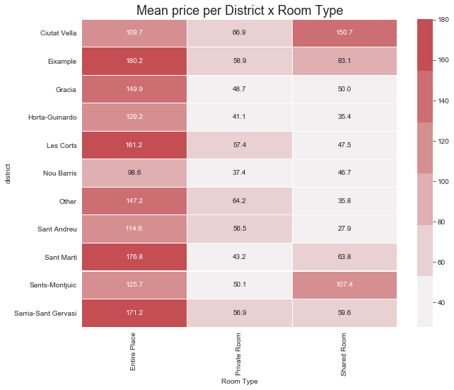

```python
f,ax=plt.subplots(figsize=(10,8))
plot = geo_df.groupby(['district','room_type'],as_index=False)\
            .agg({'avg_price':[('mean','mean')]}) \
            .pivot(index='district', columns='room_type')
sns.heatmap(data=plot, annot=True, fmt='0.1f', cmap=sns.light_palette(sns_c[3]),
            ax=ax,linecolor='white',linewidth=0.1)
ax.set_xticklabels(['Entire Place','Private Room','Shared Room'],rotation=90)
ax.set_title('Mean price per District x Room Type',fontsize=18)
ax.set_xlabel('Room Type')
```

```python
geo_df.room_type.value_counts()
```

```
entire_home     7503
private_room    6512
shared_room      147
Name: room_type, dtype: int64
```

A few neighborhoods stick out.

The dataset contained polygons for the district shapes, with which we can plot the city itself with the corresponding average district prices.

```python
border_map['coords'] = border_map['geometry'].apply(lambda x: x.representative_point().coords[:])
border_map['coords'] = [coords[0] for coords in border_map['coords']]
```

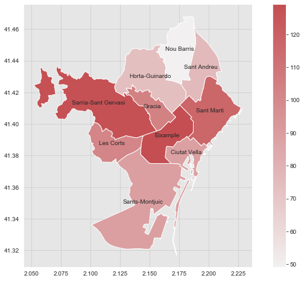

```python
f,ax = plt.subplots(figsize=(12,8))
border_map.merge(geo_df.groupby(['district']).avg_price.mean().to_frame(),
                left_on='NOM',right_on='district', how='left') \
                .plot(column='avg_price',
                     legend=True,
                     ax=ax,
                     cmap=sns.light_palette(sns_c[3],as_cmap=True))
#for idx, row in border_map.iterrows():
#    plt.annotate(s=row['NOM'], xy=border_map.geometry.centroid[idx].coords[:][0],
#                 ha='center')
_=border_map.apply(lambda x: ax.annotate(s=x.NOM,
                                       xy=x.geometry.centroid.coords[0],
                                       ha='center',
                                       fontsize=10),
                 axis=1)
```

# Linear Regression model.

After analyzing the features and their relationship to the price, it's interesting to see, if a simple regression modal can be fitted to predict the average price of a listing.

```python
from sklearn.linear_model import LinearRegression
from sklearn.preprocessing import StandardScaler
from sklearn.model_selection import train_test_split, cross_val_score
from sklearn.tree import DecisionTreeRegressor

scaler = StandardScaler()
reg = LinearRegression(fit_intercept=True)
```

```python
num_features= ['num_guests','num_bedrooms','num_beds','num_bath', 'reviews_score',
               'listing_lat','listing_long','num_H_reviews','avg_price']
cat_features=['superhost','room_type','district']
```

```python
#Merge and preprocess the data
df = price_loc.merge(
    geo_df.loc[:, ['listing_id','district']], on='listing_id', how='left')
num_data = pd.DataFrame(
    scaler.fit_transform(price_loc.loc[:, num_features]), columns=num_features)
cat_data = pd.get_dummies(
    df.loc[:,cat_features], columns=cat_features, drop_first=True)
X = pd.concat([num_data, cat_data],axis=1)
y= X.pop('avg_price')
```

```python
pd.concat([num_data, cat_data], axis=1).info()
```

```
<class 'pandas.core.frame.DataFrame'>
RangeIndex: 14162 entries, 0 to 14161
Data columns (total 22 columns):
 #   Column                        Non-Null Count  Dtype
---  ------                        --------------  -----
 0   num_guests                    14162 non-null  float64
 1   num_bedrooms                  14162 non-null  float64
 2   num_beds                      14162 non-null  float64
 3   num_bath                      14162 non-null  float64
 4   reviews_score                 10246 non-null  float64
 5   listing_lat                   14162 non-null  float64
 6   listing_long                  14162 non-null  float64
 7   num_H_reviews                 13542 non-null  float64
 8   avg_price                     14162 non-null  float64
 9   superhost_True                14162 non-null  uint8
 10  room_type_private_room        14162 non-null  uint8
 11  room_type_shared_room         14162 non-null  uint8
 12  district_Eixample             14162 non-null  uint8
 13  district_Gracia               14162 non-null  uint8
 14  district_Horta-Guinardo       14162 non-null  uint8
 15  district_Les Corts            14162 non-null  uint8
 16  district_Nou Barris           14162 non-null  uint8
 17  district_Other                14162 non-null  uint8
 18  district_Sant Andreu          14162 non-null  uint8
 19  district_Sant Marti           14162 non-null  uint8
 20  district_Sants-Montjuic       14162 non-null  uint8
 21  district_Sarria-Sant Gervasi  14162 non-null  uint8
dtypes: float64(9), uint8(13)
memory usage: 1.1 MB
```

```python
X.num_H_reviews.fillna(0, inplace=True) # Fill with 0.
X.reviews_score.fillna(X.reviews_score.median(), inplace=True)
```

```python
X_train, X_test, y_train, y_test = train_test_split(X, y ,
                                                    test_size=0.2,
                                                    random_state=42, shuffle=True)
```

```python
scores = cross_val_score(reg, X, y, cv=5,
                         verbose=1, scoring='neg_root_mean_squared_error')
```

```
[Parallel(n_jobs=1)]: Using backend SequentialBackend with 1 concurrent workers.
[Parallel(n_jobs=1)]: Done   5 out of   5 | elapsed:    0.1s finished
```

```python
def rescale_score(s):
    r=s * df.avg_price.std() + df.avg_price.mean()
    return r
```

```python
rescale_score(-scores)
```

```
array([230.74276938, 244.46994335, 188.52603832, 211.06708875,
       209.83950477])
```

```python
tree = DecisionTreeRegressor()
tree_scores = cross_val_score(tree, X ,y , cv=5,verbose=1,scoring='neg_root_mean_squared_error')
rescale_score(-tree_scores)
```

```
[Parallel(n_jobs=1)]: Using backend SequentialBackend with 1 concurrent workers.
[Parallel(n_jobs=1)]: Done   5 out of   5 | elapsed:    0.7s finished
```

```
array([278.29712421, 280.12414866, 225.08535952, 234.40602364,
       237.28889478])
```

```python
from sklearn.svm import SVR

svm = SVR(kernel='rbf', C=10)
svm_scores = cross_val_score(
    svm, X ,y , cv=5, verbose=1, scoring='neg_root_mean_squared_error')
```

```
[Parallel(n_jobs=1)]: Using backend SequentialBackend with 1 concurrent workers.
[Parallel(n_jobs=1)]: Done   5 out of   5 | elapsed:  1.4min finished
```

```python
rescale_score(-svm_scores)
```

```
array([231.6446407 , 246.90977613, 184.48802727, 206.03714382,
       205.61228146])
```

```python
hist = dict()
hist['linreg'] = rescale_score(-scores).mean()
hist['tree'] = rescale_score(-tree_scores).mean()
hist['svm'] = rescale_score(-svm_scores).mean()
```

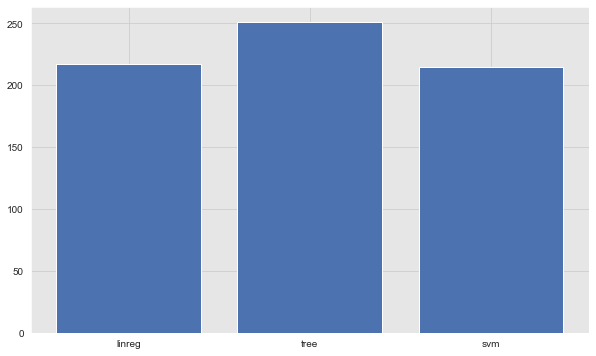

```python
plt.bar(range(len(hist)), list(hist.values()), align='center')
_=plt.xticks(range(len(hist)), list(hist.keys()))
```

```python
svm = SVR(kernel='rbf', C=10)
svm.fit(X_train, y_train)
```

```
SVR(C=10, cache_size=200, coef0=0.0, degree=3, epsilon=0.1, gamma='scale',
    kernel='rbf', max_iter=-1, shrinking=True, tol=0.001, verbose=False)
```

```python
print(f'Test score: {svm.score(X_test, y_test)}')
print(f'Train score: {svm.score(X_train, y_train)}')
```

```
Test score: 0.4199782384195234
Train score: 0.5286834754964582
```

We are overfitting the model. Use regularization.

```python
def fit_score(model):
    model.fit(X_train, y_train)
    print(f'Test score: {model.score(X_test, y_test)}')
    print(f'Train score: {model.score(X_train, y_train)}')
```

```python
fit_score(SVR(kernel='rbf', C=1, gamma='auto'))
```

```
Test score: 0.38098011392775444
Train score: 0.3738541794613562
```

No overfitting anymore with C=1. Let's look at the errors.

```python
svm = SVR(kernel='rbf', C=1, gamma='auto')
svm.fit(X, y)
y_pred = svm.predict(X)
```

```python
from sklearn.metrics import mean_squared_error

errors = y - y_pred
mse = mean_squared_error(y, y_pred)
rmse = np.sqrt(mse)
rmse_reverse_scale = rescale_score(rmse)
print(f'RMSE: {rmse} (before inverse scaling)')
print(f'RMSE: {round(rmse_reverse_scale, 2)}€ (after inverse scaling)')
```

```
RMSE: 0.7852249357758412 (before inverse scaling)
RMSE: 211.75€ (after inverse scaling)
```

```python
error_df = pd.concat([df.loc[X.index],
                      pd.Series(y, name='true'),
                      pd.Series(y_pred, name='pred', index=X.index),
                      pd.Series(errors, name='errors')],
                     axis=1)
```

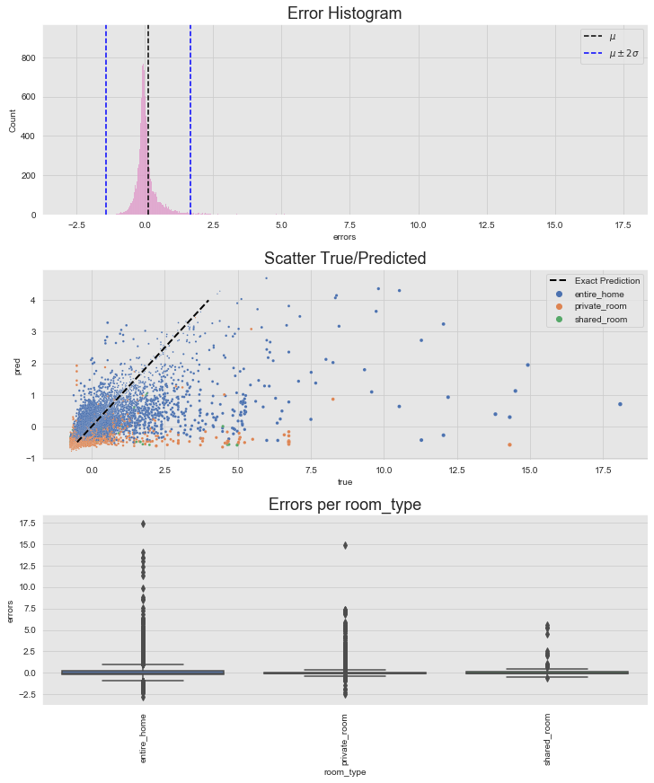

```python
sns.set_style(style='darkgrid',
    rc={'axes.facecolor': '.9', 'grid.color': '.8'})

f, axes = plt.subplots(3,1, figsize=(10,12), constrained_layout=True)

sns.histplot(data=error_df, x='errors', color=sns_c[6], ax=axes[0])
axes[0].axvline(x=error_df.errors.mean(),
              color='black', linestyle='--', label=f'$\mu$')
axes[0].axvline(x=error_df.errors.mean() + 2 * error_df.errors.std(),
              color='blue', linestyle='--', label=f'$\mu\pm2\sigma$')
axes[0].axvline(x=error_df.errors.mean() - 2 * error_df.errors.std(),
              color='blue', linestyle='--')

sns.scatterplot(data=error_df, x='true', y='pred',
                color=sns_c[6],
                ax=axes[1],
                markers='o',
                s=np.sqrt(np.abs(error_df.errors))*5,
                hue='room_type')
axes[1].plot([-0.5, 4], [-0.5, 4], linestyle='--', lw=2, color='black', label='Exact Prediction')

sns.boxplot(data=error_df, x='room_type', y='errors',ax=axes[2])
plt.xticks(rotation=90)

axes[0].legend()
axes[0].set_title('Error Histogram', fontsize=18)
axes[1].set_title('Scatter True/Predicted', fontsize=18)
axes[2].set_title('Errors per room_type', fontsize=18)
_=axes[1].legend()
```

The distribution of the errors show a few extremely high errors, with up to 15 times the std. The error analysis shows, that the model performs well for low and medium priced listing, while very expensive ones are underpredicted severely. Underpredicting the price seems to be a general problem, where entire_home listings are most affected.

The improve the model, features to detect high value listings should be explored and added to the model.

```python
mapper_lat = dict(zip(pd.cut(df.listing_lat, 5).value_counts().index, range(5)))
mapper_long = dict(zip(pd.cut(df.listing_long, 5).value_counts().index, range(5)))

df = df.assign(lat_bin=pd.cut(df.listing_lat, 5) \
                .replace(mapper_lat)) \
            .assign(long_bin=pd.cut(df.listing_long, 5) \
                .replace(mapper_long))
df['loc_bin'] = np.zeros(len(df))
for i in range(len(df)):
    df.iloc[i,-1] = str((df.lat_bin[i], df.long_bin[i]))
```

```python
bins_features = pd.get_dummies(df.loc_bin, drop_first=True)
X_bin = pd.concat([X,bins_features], axis=1)#.dropna()
X_train_bin = X_bin.loc[X_train.index]
X_test_bin = X_bin.loc[X_test.index]
```

```python
svm = SVR(kernel='rbf', C=1, gamma='auto')
svm_scores = cross_val_score(svm, X_train_bin, y_train , cv=5,verbose=1)
print('Scores:',svm_scores)
```

```
[Parallel(n_jobs=1)]: Using backend SequentialBackend with 1 concurrent workers.
```

```
Scores: [0.33825783 0.3479544  0.36124078 0.29735906 0.39761765]
```

```
[Parallel(n_jobs=1)]: Done   5 out of   5 | elapsed:   37.8s finished
```

```python
svm.fit(X_train_bin, y_train)
print(f'Test score: {svm.score(X_test_bin, y_test)}')
print(f'Train score: {svm.score(X_train_bin, y_train)}')
```

```
Test score: 0.3777036703596981
Train score: 0.36798212624922405
```

```python
y_pred = svm.predict(X_bin)

errors = y - y_pred
mse = mean_squared_error(y, y_pred)
rmse = np.sqrt(mse)
rmse_reverse_scale = rescale_score(rmse)
print(f'RMSE: {rmse} (before inverse scaling)')
print(f'RMSE: {round(rmse_reverse_scale, 2)}€ (after inverse scaling)')
```

```
RMSE: 0.793845693239634 (before inverse scaling)
RMSE: 212.89€ (after inverse scaling)
```

Adding the location feature hasnt enhanced the model.

### Conclusion

Predicting the nightly price with the features at hand is not very accurate. More feature engineering would be necessary to achieve satisfying scores with regression models. A first idea would be to turn the title of the listing into features.